بدايةً نقوم بتضمين المكتبات الأساسيَّة كمكتبة التَّعامل مع المصفوفات نام باي ومكتبة التعامل مع الملفَّات بانداز ومكتبة الرَّسم البياني ماتبلوت ومكتبة اس كي للتَّعلُّم لبناء النموذج

```python
import pandas as pd
import matplotlib.pyplot as plt
import sklearn as sk
```

raed_csv نقوم بقراءة ملف قاعدة البيانات آيريس باستخدام تابع القراءة

```python
data = pd.read_csv("iris.csv")
```

نقوم بعزل البيانات (الأعمدة الأربعة الأولى) عن عمود القرار (العمود الخامس) لتكون بيانات دخلٍ لعمليَّة التَّدريب

```python
x = data.iloc[:,:4]
```

نقوم بعزل عمود القرار ليتم مقارنته مع نتيجة التَّدريب

```python
y = data.iloc[:,4:]
```

لتقسيم البيانات بنسبة ثمانون بالمئة للتدريب وعشرون بالمئة للاختبار train_test_split نستخدم المكتبة اس كي للتَّعلُّم ونستدعي التابع

```python
from sklearn.model_selection import train_test_split
x_train, x_test, y_train, y_test = train_test_split(x,y,test_size = 0.2,random_state = 42)
```

من مكتبة اس كي للتَّعلُّم قسم الشَّجرة وإنشاء كائن منها وسيحتوي على توابع وعمليَّات التَّصنيف DecisionTreeClaSsifier نقوم ببناء قالب النّموذج من خلال تضمين النَّموذج

```python
from sklearn.tree import DecisionTreeClassifier
dec_tree = DecisionTreeClassifier()
```

لملاءمة النَّموذج fit نستخدم التَّابع

```python
dec_tree.fit(x_train,y_train)
```

```
DecisionTreeClassifier()
```

لحساب دقِّة النَّموذج ومن ثمَّ نقوم بإظهارها score نستخدم التابع

```python
print("Decision Tree Classification Score: ",dec_tree.score(x_test,y_test))
```

```
Decision Tree Classification Score:  1.0
```

لرسم الشّجرة النِّهائيَّة للنَّموذج وثمّ نقوم بإظهارها plot_tree نستخدم التابع

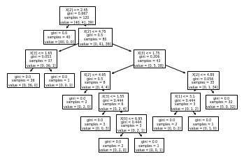

```python
sk.tree.plot_tree(dec_tree)
plt.show()
```